# Q.3a Report

### Applying data augmentation

In this step we will increase the size of our dataset by applying data augmentation to the original dataset. From what we expect to see in our test dataset we choose augmentation techniques from available augmentations from $\textbf{torch.transforms}$.

We first tried different augmentation techniques and observed the training and validation accuracy. After minimizing our choices depending on the accuracy we moved on to tuning hyperparameters for the choosen augmentations. Then we tried to compose the choosen augmenations in different orders which didn't have a huge impact on the accuracy. So we moved on to appylying the tuned augmentations using RandomApply method which seemed to have a better impact as a more diverse dataset were created.

#### First round of augmentations

- torchvision.transforms.CenterCrop()
- torchvision.transforms.ColorJitter()
- torchvision.transforms.FiveCrop()
- torchvision.transforms.Grayscale()
- torchvision.transforms.RandomAffine()
- torchvision.transforms.RandomHorizontalFlip()
- torchvision.transforms.RandomResizedCrop()
- torchvision.transforms.RandomVerticalFlip()

#### Second round of augmentation with hyperparameter tuned in

- torchvision.transforms.CenterCrop(32)
- torchvision.transforms.RandomResizedCrop(32)
- torchvision.transforms.ColorJitter(brightness=0.5,contrast=0.5,saturation=0.2, hue = 0.4)
- torchvision.transforms.Grayscale(num_output_channels=3)
- torchvision.transforms.RandomAffine(degrees=(-15,15), scale = [0.95, 1.05], translate = (0.1, 0.1))
- torchvision.transforms.RandomHorizontalFlip(p = 1.0)

#### Final round of augmentation choosen

- torchvision.transforms.RandomAffine(degrees=(-15,15), scale = [0.95, 1.05], translate = (0.1, 0.1))
- torchvision.transforms.RandomHorizontalFlip(p = 1.0)

#### Full augmentation applied

- transforms.RandomApply([torchvision.transforms.RandomAffine(degrees=(-15,15), scale = [0.95, 1.05], translate = (0.1, 0.1)), torchvision.transforms.RandomHorizontalFlip(p = 1.0)], p = 0.5)

The model is run for 30 epochs which results in 85% accuracy.

#### Plot of model with data augmentation

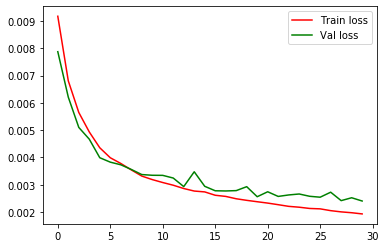

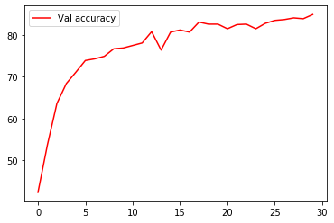

```python
import matplotlib.pyplot as plt

plt.figure(2)
plt.plot(loss_train, 'r', label='Train loss')
plt.plot(loss_val, 'g', label='Val loss')
plt.legend()
plt.show()

plt.figure(3)
plt.plot(accuracy_val, 'r', label='Val accuracy')
plt.legend()
plt.show()
```